# NguyenNamHongDoan_Project

2025-02-18

## 2

```r
library(tidyverse)
investment <- read_csv("investment_transactions.csv")
```

```
## ──────────────────────────────────────────────────────── Delimiter: "," chr
## (3): company, sector, investment dbl (20): ...1, horizon (days), amount,
## price_BUY, price_SELL, Volatility_B... date (2): date_BUY_fix, date_SELL_fix
```

```r
head(investment)
```

```
## # A tibble: 6 × 25
##    ...1 company sector `horizon (days)` amount date_BUY_fix date_SELL_fix
##   <dbl> <chr>   <chr>             <dbl>  <dbl> <date>       <date>
## 1     0 BBY     RETAIL                2    100 2017-05-25   2017-05-26
## 2     1 BAC     BANK                330  15000 2016-11-22   2017-10-18
## 3     2 AXP     BANK                  7   3000 2016-09-27   2016-10-04
## 4     3 KSS     RETAIL                5  20000 2016-10-11   2016-10-17
## 5     4 JPM     BANK                360  15000 2015-03-12   2016-03-07
## 6     5 PEP     FMCG                 15  50000 2016-09-09   2016-09-23
## # ℹ 18 more variables: price_BUY <dbl>, price_SELL <dbl>, Volatility_Buy <dbl>,
## #   Volatility_sell <dbl>, `Sharpe Ratio` <dbl>,
## #   `expected_return (yearly)` <dbl>, inflation <dbl>, nominal_return <dbl>,
## #   investment <chr>, ESG_ranking <dbl>, PE_ratio <dbl>, EPS_ratio <dbl>,
## #   PS_ratio <dbl>, PB_ratio <dbl>, NetProfitMargin_ratio <dbl>,
## #   current_ratio <dbl>, roa_ratio <dbl>, roe_ratio <dbl>
```

## 3

```r
str(investment)
```

```
## spc_tbl_ [405,258 × 25] (S3: spec_tbl_df/tbl_df/tbl/data.frame)
##  $ ...1                    : num [1:405258] 0 1 2 3 4 5 7 8 9 10 ...
##  $ company                 : chr [1:405258] "BBY" "BAC" "AXP" "KSS" ...
##  $ sector                  : chr [1:405258] "RETAIL" "BANK" "BANK" "RETAIL" ...
##  $ horizon (days)          : num [1:405258] 2 330 7 5 360 15 720 600 30 6 ...
##  $ amount                  : num [1:405258] 100 15000 3000 20000 15000 50000 1500 300 50000 400 ...
##  $ date_BUY_fix            : Date[1:405258], format: "2017-05-25" "2016-11-22" ...
##  $ date_SELL_fix           : Date[1:405258], format: "2017-05-26" "2017-10-18" ...
##  $ price_BUY               : num [1:405258] 55.6 18.6 59.9 38.2 51.9 ...
##  $ price_SELL              : num [1:405258] 53.5 24.7 59.5 36 52 ...
##  $ Volatility_Buy          : num [1:405258] 0.384 0.323 0.239 0.429 0.195 ...
##  $ Volatility_sell         : num [1:405258] 0.386 0.236 0.235 0.429 0.254 ...
##  $ Sharpe Ratio            : num [1:405258] 0.384 0.323 0.239 0.429 0.195 ...
##  $ expected_return (yearly): num [1:405258] 1.44e-03 1.71e-01 2.82e-03 9.39e-05 1.50e-01 ...
##  $ inflation               : num [1:405258] 1.96 -0.2 -0.2 -0.2 -0.5 -0.2 -0.15 -0.2 -0.5 -0.2 ...
##  $ nominal_return          : num [1:405258] -0.03722 0.32432 -0.00576 -0.05839 0.00344 ...
##  $ investment              : chr [1:405258] "BAD" "GOOD" "BAD" "BAD" ...
##  $ ESG_ranking             : num [1:405258] 12 26.3 19.8 12.9 27.9 17.6 31.6 24.8 26.3 27.9 ...
##  $ PE_ratio                : num [1:405258] 12.58 11.39 10.58 11.09 9.38 ...
##  $ EPS_ratio               : num [1:405258] 3.73 1.26 5.64 3.27 5.46 4.56 1.05 1.71 0.96 5.99 ...
##  $ PS_ratio                : num [1:405258] 0.38 1.71 1.67 0.36 1.87 ...
##  $ PB_ratio                : num [1:405258] 3.19 0.54 2.6 1.25 0.81 ...
##  $ NetProfitMargin_ratio   : num [1:405258] 3.01 15.7 15.68 3.17 19.91 ...
##  $ current_ratio           : num [1:405258] 1.49 0.92 1.91 1.6 0.99 ...
##  $ roa_ratio               : num [1:405258] 8.69 0.67 3.39 4.41 0.81 ...
##  $ roe_ratio               : num [1:405258] 26.69 5.54 25.78 11.35 8.91 ...
##  - attr(*, "spec")=
##   .. cols(
##   ..   ...1 = col_double(),
##   ..   company = col_character(),
##   ..   sector = col_character(),
##   ..   `horizon (days)` = col_double(),
##   ..   amount = col_double(),
##   ..   date_BUY_fix = col_date(format = ""),
##   ..   date_SELL_fix = col_date(format = ""),
##   ..   price_BUY = col_double(),
##   ..   price_SELL = col_double(),
##   ..   Volatility_Buy = col_double(),
##   ..   Volatility_sell = col_double(),
##   ..   `Sharpe Ratio` = col_double(),
##   ..   `expected_return (yearly)` = col_double(),
##   ..   inflation = col_double(),
##   ..   nominal_return = col_double(),
##   ..   investment = col_character(),
##   ..   ESG_ranking = col_double(),
##   ..   PE_ratio = col_double(),
##   ..   EPS_ratio = col_double(),
##   ..   PS_ratio = col_double(),
##   ..   PB_ratio = col_double(),
##   ..   NetProfitMargin_ratio = col_double(),
##   ..   current_ratio = col_double(),
##   ..   roa_ratio = col_double(),
##   ..   roe_ratio = col_double()
##   .. )
##  - attr(*, "problems")=<externalptr>
```

## 4

```r
summary(investment)
```

```
##       ...1          company             sector          horizon (days)
##  Min.   :     0   Length:405258      Length:405258      Min.   :  1.0
##  1st Qu.:125063   Class :character   Class :character   1st Qu.: 15.0
##  Median :249938   Mode  :character   Mode  :character   Median : 90.0
##  Mean   :249936                                         Mean   :187.1
##  3rd Qu.:374755                                         3rd Qu.:300.0
##  Max.   :499999                                         Max.   :720.0
##      amount       date_BUY_fix        date_SELL_fix          price_BUY
##  Min.   :   50   Min.   :2013-10-10   Min.   :2013-10-11   Min.   :   7.137
##  1st Qu.:  400   1st Qu.:2015-02-23   1st Qu.:2015-08-18   1st Qu.:  28.303
##  Median : 2000   Median :2016-05-19   Median :2016-11-21   Median :  46.218
##  Mean   : 8108   Mean   :2016-05-10   Mean   :2016-11-13   Mean   : 105.256
##  3rd Qu.:10000   3rd Qu.:2017-08-08   3rd Qu.:2018-02-12   3rd Qu.:  76.289
##  Max.   :50000   Max.   :2018-10-09   Max.   :2020-09-28   Max.   :2039.510
##    price_SELL      Volatility_Buy    Volatility_sell    Sharpe Ratio
##  Min.   :   4.01   Min.   :0.09042   Min.   :0.09042   Min.   :0.09042
##  1st Qu.:  28.39   1st Qu.:0.18536   1st Qu.:0.18900   1st Qu.:0.18536
##  Median :  48.02   Median :0.23220   Median :0.23813   Median :0.23220
##  Mean   : 116.73   Mean   :0.25414   Mean   :0.25969   Mean   :0.25414
##  3rd Qu.:  81.65   3rd Qu.:0.30673   3rd Qu.:0.31648   3rd Qu.:0.30673
##  Max.   :3450.96   Max.   :0.69756   Max.   :0.92253   Max.   :0.69756
##  expected_return (yearly)   inflation       nominal_return
##  Min.   :-0.278002        Min.   :-0.5000   Min.   :-0.87222
##  1st Qu.: 0.001059        1st Qu.:-0.2000   1st Qu.:-0.02837
##  Median : 0.012843        Median :-0.1500   Median : 0.01410
##  Mean   : 0.070825        Mean   : 0.5777   Mean   : 0.07102
##  3rd Qu.: 0.082635        3rd Qu.: 1.6800   3rd Qu.: 0.11124
##  Max.   : 1.017344        Max.   : 1.9600   Max.   : 8.84703
##   investment         ESG_ranking       PE_ratio         EPS_ratio
##  Length:405258      Min.   :12.00   Min.   :   0.00   Min.   :-6.560
##  Class :character   1st Qu.:16.30   1st Qu.:   9.82   1st Qu.: 1.460
##  Mode  :character   Median :25.10   Median :  13.71   Median : 2.960
##                     Mean   :22.57   Mean   :  30.33   Mean   : 3.443
##                     3rd Qu.:27.90   3rd Qu.:  23.49   3rd Qu.: 4.560
##                     Max.   :31.60   Max.   :1116.57   Max.   :29.870
##     PS_ratio         PB_ratio      NetProfitMargin_ratio current_ratio
##  Min.   : 0.160   Min.   : 0.000   Min.   :-24.630       Min.   : 0.610
##  1st Qu.: 0.470   1st Qu.: 1.220   1st Qu.:  2.620       1st Qu.: 0.980
##  Median : 1.710   Median : 3.050   Median :  7.700       Median : 1.220
##  Mean   : 2.725   Mean   : 4.688   Mean   :  9.205       Mean   : 2.173
##  3rd Qu.: 3.180   3rd Qu.: 5.230   3rd Qu.: 15.770       3rd Qu.: 1.790
##  Max.   :24.490   Max.   :47.620   Max.   : 62.000       Max.   :13.560
##    roa_ratio         roe_ratio
##  Min.   :-12.990   Min.   :-99.49
##  1st Qu.:  1.740   1st Qu.:  8.83
##  Median :  5.710   Median : 16.10
##  Mean   :  5.596   Mean   : 15.64
##  3rd Qu.:  7.990   3rd Qu.: 26.03
##  Max.   : 38.130   Max.   : 57.25
```

### 5

Binary: investment Nominal (Categorical, No Order): company, sector Ordinal (Categorical, Has Order): ESG_ranking Discrete: horizon (days), inflation Continuous: price_BUY, price_SELL, PE_ratio, EPS_ratio

## 6

1. Is there a correlation between ESG ranking and return on equity?
2. How does the volatility of an asset impact its sharpe ratio?
3. Do investments in the bank sector have higher expected returns than those in retail?

## 7

## Analyze the relationship between buy and sell price

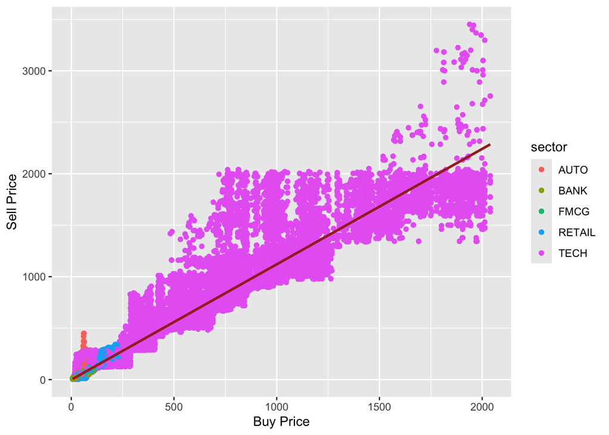

```r
ggplot(investment, aes(x = price_BUY, y = price_SELL, colour = sector)) +
  geom_point() +
  geom_smooth(method="lm", color = "brown") +
  labs(
       x = "Buy Price",
       y = "Sell Price")
```

## 8

## Measure how buy volatility ratio affect the amount of return

```r
investment <- investment %>%
  mutate(return_volatility_ratio = nominal_return / Volatility_Buy)
head(investment)
```

```
## # A tibble: 6 × 26
##    ...1 company sector `horizon (days)` amount date_BUY_fix date_SELL_fix
##   <dbl> <chr>   <chr>             <dbl>  <dbl> <date>       <date>
## 1     0 BBY     RETAIL                2    100 2017-05-25   2017-05-26
## 2     1 BAC     BANK                330  15000 2016-11-22   2017-10-18
## 3     2 AXP     BANK                  7   3000 2016-09-27   2016-10-04
## 4     3 KSS     RETAIL                5  20000 2016-10-11   2016-10-17
## 5     4 JPM     BANK                360  15000 2015-03-12   2016-03-07
## 6     5 PEP     FMCG                 15  50000 2016-09-09   2016-09-23
## # ℹ 19 more variables: price_BUY <dbl>, price_SELL <dbl>, Volatility_Buy <dbl>,
## #   Volatility_sell <dbl>, `Sharpe Ratio` <dbl>,
## #   `expected_return (yearly)` <dbl>, inflation <dbl>, nominal_return <dbl>,
## #   investment <chr>, ESG_ranking <dbl>, PE_ratio <dbl>, EPS_ratio <dbl>,
## #   PS_ratio <dbl>, PB_ratio <dbl>, NetProfitMargin_ratio <dbl>,
## #   current_ratio <dbl>, roa_ratio <dbl>, roe_ratio <dbl>,
## #   return_volatility_ratio <dbl>
```

## 9

## Compare 2 sectors in term of return on assets ratio

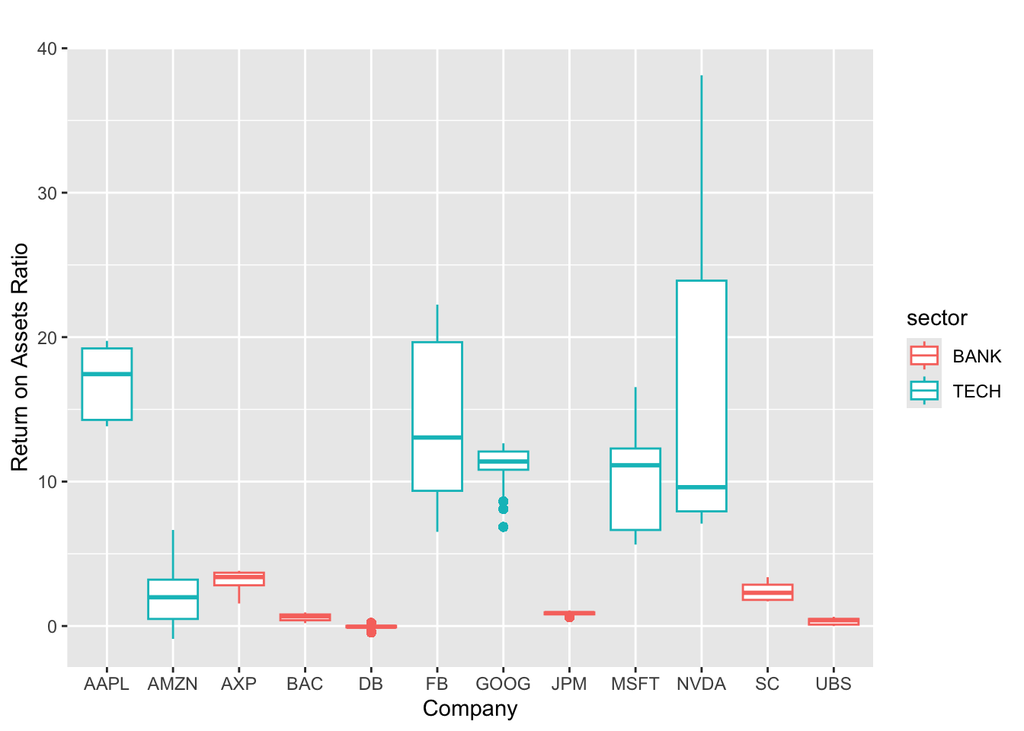

```r
investment %>%
  filter(sector %in% c("BANK", "TECH")) %>%
  ggplot(aes(x = company, y = roa_ratio, colour = sector)) +
  geom_boxplot() +
  labs(title = "",
       x = "Company",
       y = "Return on Assets Ratio")
```

## Pearson correlation between buy and sell price

```r
cor.test(investment$price_BUY, investment$price_SELL)
```

```
##
##  Pearson's product-moment correlation
##
## data:  investment$price_BUY and investment$price_SELL
## t = 2713.6, df = 405256, p-value < 2.2e-16
## alternative hypothesis: true correlation is not equal to 0
## 95 percent confidence interval:
##  0.9734076 0.9737288
## sample estimates:
##       cor
## 0.9735687
```

## Evaluate the net profit percentage of highest-trading-volume sector with lowest one to find out if company’s profit lead to buy/sell decision

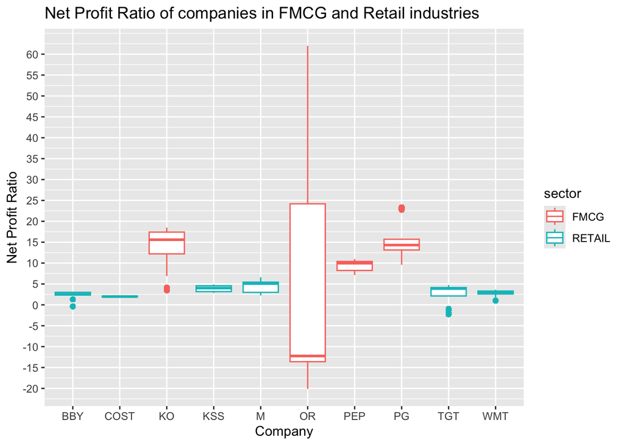

```r
filtered_company <- investment %>%
  filter(sector %in% c("RETAIL", "FMCG"))

# Create the boxplot
ggplot(filtered_company, aes(x = company, y = NetProfitMargin_ratio, colour = sector)) +
  geom_boxplot() +
  scale_y_continuous(
    breaks = seq(-20, 60, by = 5)
  ) +
  labs(title = "Net Profit Ratio of companies in FMCG and Retail industries",
       x = "Company",
       y = "Net Profit Ratio")
```

```r
lr_amount <- lm(amount ~ NetProfitMargin_ratio, data = investment)
summary(lr_amount)
```

```
##
## Call:
## lm(formula = amount ~ NetProfitMargin_ratio, data = investment)
##
## Residuals:
##    Min     1Q Median     3Q    Max
##  -8097  -7713  -6107   1896  41916
##
## Coefficients:
##                        Estimate Std. Error t value Pr(>|t|)
## (Intercept)           8101.8401    26.7901 302.419   <2e-16 ***
## NetProfitMargin_ratio    0.7208     1.9282   0.374    0.709
## ---
## Signif. codes:  0 '***' 0.001 '**' 0.01 '*' 0.05 '.' 0.1 ' ' 1
##
## Residual standard error: 12770 on 405256 degrees of freedom
## Multiple R-squared:  3.448e-07,  Adjusted R-squared:  -2.123e-06
## F-statistic: 0.1397 on 1 and 405256 DF,  p-value: 0.7086
```

```r
result <- investment %>%
  group_by(sector) %>%
  summarize(total_amount = sum(amount))
```

## Find out which pair of variables has probably high relationship and analyze those 2 variables

```r
cor(select(investment, Volatility_Buy, Volatility_sell,
    `Sharpe Ratio`, `expected_return (yearly)`, inflation,
    nominal_return, ESG_ranking, PE_ratio, EPS_ratio,
    PS_ratio, PB_ratio, NetProfitMargin_ratio,
    current_ratio, roa_ratio, roe_ratio))
```

```
##                          Volatility_Buy Volatility_sell Sharpe Ratio
## Volatility_Buy               1.00000000     0.852705439   1.00000000
## Volatility_sell              0.85270544     1.000000000   0.85270544
## Sharpe Ratio                 1.00000000     0.852705439   1.00000000
## expected_return (yearly)     0.14766653     0.177266824   0.14766653
## inflation                   -0.02807268     0.005471885  -0.02807268
## nominal_return               0.09683867     0.038153289   0.09683867
## ESG_ranking                 -0.05356711    -0.084553657  -0.05356711
## PE_ratio                     0.01532091     0.014358800   0.01532091
## EPS_ratio                   -0.23356359    -0.219637353  -0.23356359
## PS_ratio                     0.20241612     0.157122351   0.20241612
## PB_ratio                     0.24933367     0.213714805   0.24933367
## NetProfitMargin_ratio       -0.24938448    -0.258394514  -0.24938448
## current_ratio                0.13200913     0.119144209   0.13200913
## roa_ratio                   -0.17441801    -0.154855610  -0.17441801
## roe_ratio                   -0.33622431    -0.319713475  -0.33622431
##                          expected_return (yearly)    inflation nominal_return
## Volatility_Buy                         0.14766653 -0.028072684   0.0968386675
## Volatility_sell                        0.17726682  0.005471885   0.0381532894
## Sharpe Ratio                           0.14766653 -0.028072684   0.0968386675
## expected_return (yearly)               1.00000000 -0.017545355   0.5445277752
## inflation                             -0.01754536  1.000000000  -0.0196484720
## nominal_return                         0.54452778 -0.019648472   1.0000000000
## ESG_ranking                           -0.05622371  0.002659846  -0.1028333144
## PE_ratio                               0.10173492 -0.012094411   0.0488518161
## EPS_ratio                              0.01155042  0.080124191   0.0091221055
## PS_ratio                               0.28146616  0.067224578   0.0831480874
## PB_ratio                               0.34330478  0.021116544   0.0833333672
## NetProfitMargin_ratio                  0.06670842  0.050553077   0.0712797646
## current_ratio                          0.15983150  0.019586820   0.0787948320
## roa_ratio                              0.10088152  0.052811410   0.0752677544
## roe_ratio                             -0.11319679  0.071861483  -0.0009483889
##                           ESG_ranking    PE_ratio    EPS_ratio    PS_ratio
## Volatility_Buy           -0.053567109  0.01532091 -0.233563590  0.20241612
## Volatility_sell          -0.084553657  0.01435880 -0.219637353  0.15712235
## Sharpe Ratio             -0.053567109  0.01532091 -0.233563590  0.20241612
## expected_return (yearly) -0.056223714  0.10173492  0.011550417  0.28146616
## inflation                 0.002659846 -0.01209441  0.080124191  0.06722458
## nominal_return           -0.102833314  0.04885182  0.009122106  0.08314809
## ESG_ranking               1.000000000  0.11803190 -0.106311122  0.17564847
```

[output cut: 25 more lines]

```
## Volatility_Buy           -0.17441801 -0.3362243085
## Volatility_sell          -0.15485561 -0.3197134754
## Sharpe Ratio             -0.17441801 -0.3362243085
## expected_return (yearly)  0.10088152 -0.1131967881
## inflation                 0.05281141  0.0718614828
## nominal_return            0.07526775 -0.0009483889
## ESG_ranking              -0.42492550 -0.4686852996
## PE_ratio                 -0.03966815 -0.0548683508
## EPS_ratio                 0.34323368  0.2710032358
## PS_ratio                  0.32391282 -0.1098675369
## PB_ratio                 -0.04517551 -0.2715260732
## NetProfitMargin_ratio     0.70164548  0.5641896406
## current_ratio             0.41077001  0.0828058834
## roa_ratio                 1.00000000  0.7379243863
## roe_ratio                 0.73792439  1.0000000000
```

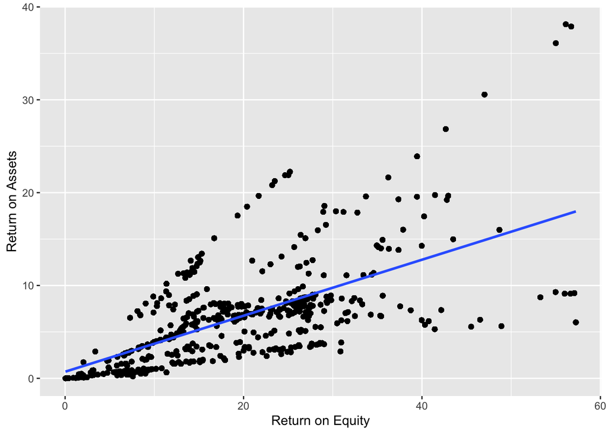

```r
investment %>%
  filter(roe_ratio > 0) %>%
  ggplot(aes(x = roe_ratio, y = roa_ratio)) +
  geom_point() +
  geom_smooth(method="lm") +
  labs(
       x = "Return on Equity",
       y = "Return on Assets")
```

```r
lr <- lm(EPS_ratio ~ NetProfitMargin_ratio, data = investment)
summary(lr)
```

```
##
## Call:
## lm(formula = EPS_ratio ~ NetProfitMargin_ratio, data = investment)
##
## Residuals:
##      Min       1Q   Median       3Q      Max
## -10.6110  -2.5860  -0.4146   1.1100  24.8869
##
## Coefficients:
##                        Estimate Std. Error t value Pr(>|t|)
## (Intercept)           2.1414106  0.0086720   246.9   <2e-16 ***
## NetProfitMargin_ratio 0.1414457  0.0006242   226.6   <2e-16 ***
## ---
## Signif. codes:  0 '***' 0.001 '**' 0.01 '*' 0.05 '.' 0.1 ' ' 1
##
## Residual standard error: 4.135 on 405256 degrees of freedom
## Multiple R-squared:  0.1125, Adjusted R-squared:  0.1125
## F-statistic: 5.135e+04 on 1 and 405256 DF,  p-value: < 2.2e-16
```

## In conclusion, the variables in investment dataset is great for evaluating the development and performance of companies as well as industries.

## However, while these variables contribute to investors’ decision-making, they don’t provide a perfect linear relationship of trading volume, as there are factors besides companies that investors need to consider.